# **Online Supplement S3**

Detailed Output for Kuskokwim River Chinook Salmon SSM-Vm

Staton et al.

# Model Description

**Model Identifier**: SSM-Vm

**Recruitment Process Error Variance**: Full covariance matrix estimated using an inverse Wishart distribution.

**Maturity Schedule**: Time- and population-constant maturation schedules.

*All other model components are the same as the other state-space models.*

# MCMC Details

## Settings

The MCMC settings used in this run.

| Option | Setting |
| --- | --- |
| Chains | 10 |
| Burn-in/Adapt | 55,000 |
| Post-Burn-in | 800,000 |
| Thinning Interval | 400 |
| Saved Iterations | 20,000 |

## Convergence Summaries

### Rhat values

Summaries of the Rhat convergence diagnostic for key parameters/states across stocks and years, where applicable.

| Parameter | Mean | Median | Min | Max |
| --- | --- | --- | --- | --- |
| $\alpha_j$ | 1.03 | 1.02 | 1.01 | 1.1 |
| $\beta_j$ | 1.06 | 1.03 | 1.02 | 1.18 |
| $U_{\text{MSY},j}$ | 1.04 | 1.03 | 1.01 | 1.18 |
| $S_{\text{MSY},j}$ | 1.05 | 1.03 | 1.01 | 1.24 |
| $\sigma_{R,j}$ | 1.05 | 1.02 | 1 | 1.16 |
| $\pi_a$ | 1 | 1 | 1 | 1 |
| $U_t$ | 1.07 | 1.01 | 1 | 1.43 |
| $\phi$ | 1.01 | 1.01 | 1.01 | 1.01 |
| $R_{y,j}$ | 1.05 | 1.01 | 1 | 4.59 |
| $S_{t,j}$ | 1.05 | 1.01 | 1 | 3.89 |

### Effective Samples

Summaries of the effective sample size diagnostic for key parameters/states across populations and years, where applicable.

| Parameter | Mean | Median | Min | Max |
| --- | --- | --- | --- | --- |
| $\alpha_j$ | 2,327 | 2,245 | 369 | 4,275 |
| $\beta_j$ | 1,625 | 1,744 | 250 | 2,199 |
| $U_{\text{MSY},j}$ | 2,134 | 1,913 | 347 | 3,895 |
| $S_{\text{MSY},j}$ | 2,835 | 2,742 | 838 | 5,013 |
| $\sigma_{R,j}$ | 1,867 | 1,354 | 448 | 4,720 |
| $\pi_a$ | 16,328 | 16,330 | 13,967 | 18,686 |
| $U_t$ | 8,320 | 5,432 | 517 | 19,820 |
| $\phi$ | 2,712 | 2,712 | 2,712 | 2,712 |
| $R_{y,j}$ | 6,064 | 3,199 | 180 | 20,932 |
| $S_{t,j}$ | 8,341 | 5,522 | 154 | 21,081 |

# Key Posterior Estimates

In these plots, the boxplot represents the marginal posterior (2.5<sup>th</sup>, 25<sup>th</sup>, 50<sup>th</sup>, 75<sup>th</sup>, and 97.5<sup>th</sup> percentiles) and the horizontal dotted represents the mean across populations.

## $\alpha_j$

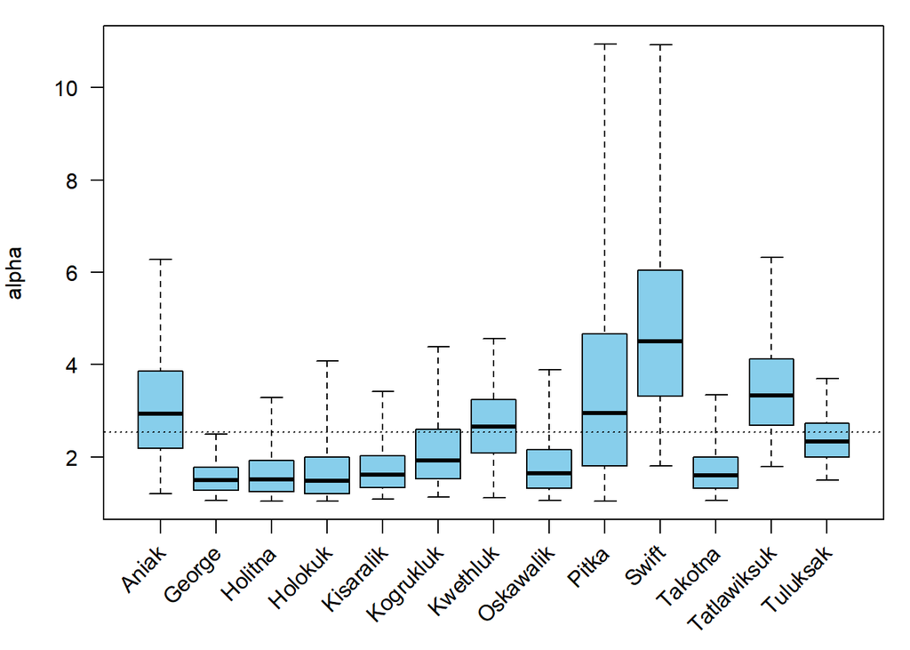

## $S_{\text{MSY},j}$

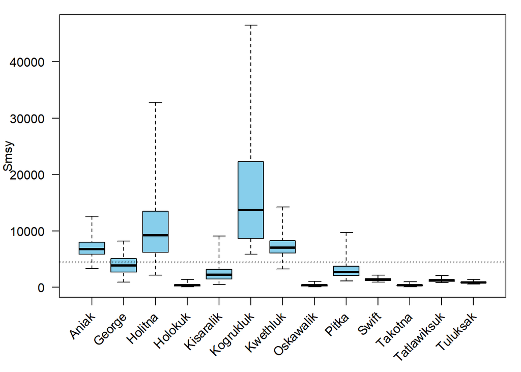

## $U_{\text{MSY},j}$

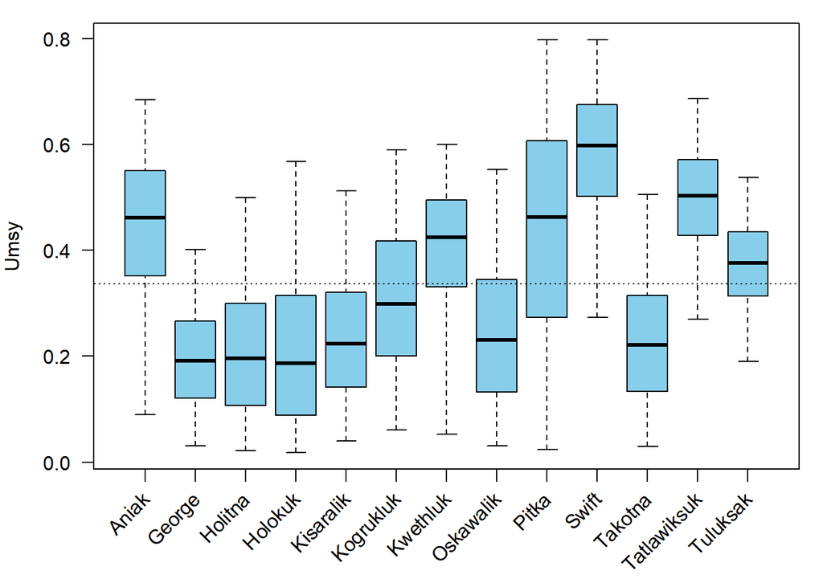

## $\phi$

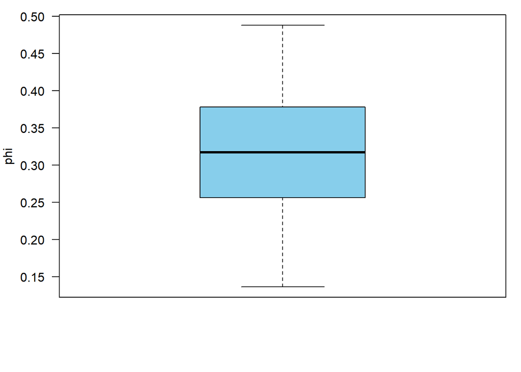

## $\sigma_{R,j}$

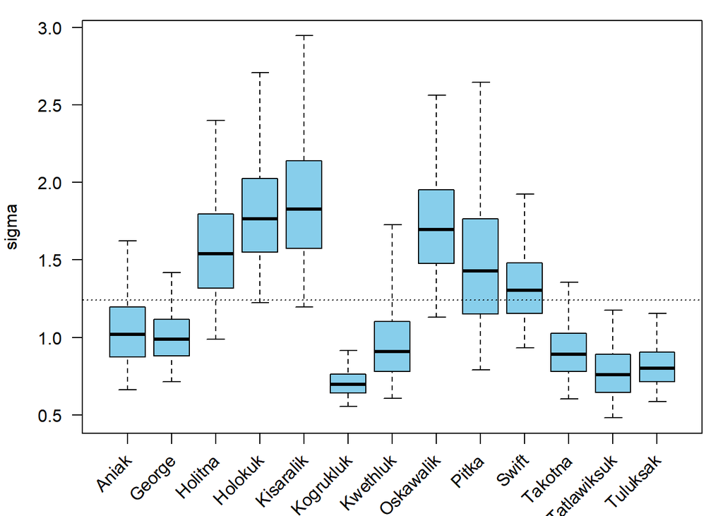

# Size vs. Productivity

In each plot, the color represents the location:

- lower river populations,
- middle river populations, and
- upper river populations,

Vertical and horizontal lines represent the mean across populations in either dimension.

## $S_{\text{MSY},j}$ vs. $U_{\text{MSY},j}$

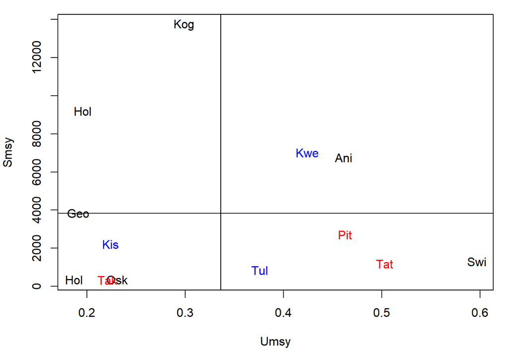

## $S_{eq,j}$ vs. $\alpha_j$

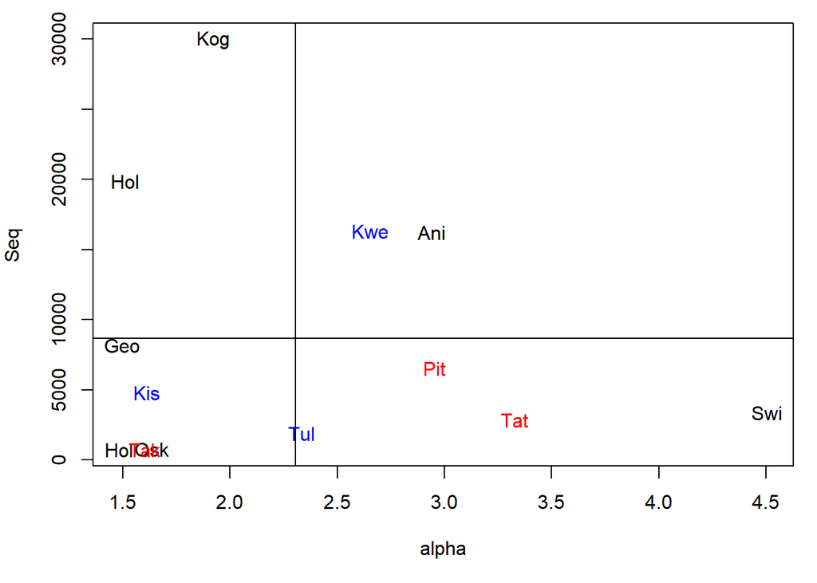

# Spawner-Recruit Relationships

Blue points are “fully-observed” spawner recruit pairs, i.e., all age-specific escapements were observed for that brood year, as well as the escapement that produced those pairs were observed.

Black points are posterior medians of the latent state pairs – only those brood years with a matching spawner abundance were used (i.e., the first 7 brood years are excluded).

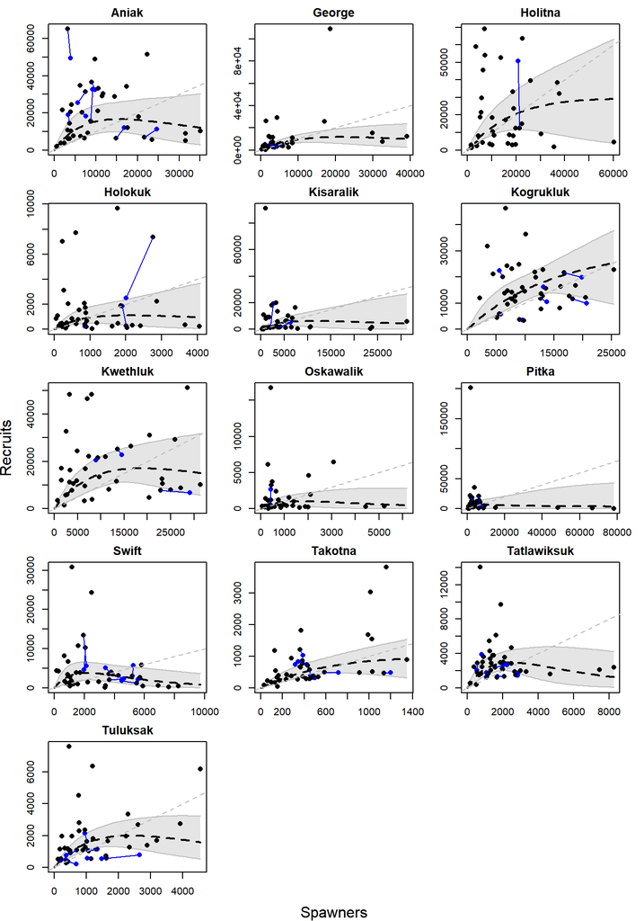

# Fit to Data

In all figures, blue points are observed data, black lines are posterior medians, and grey regions are 95% equal-tailed credible intervals.

## Escapement

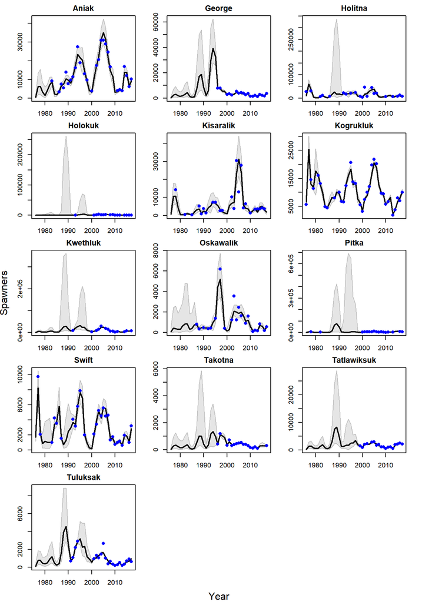

## Harvest

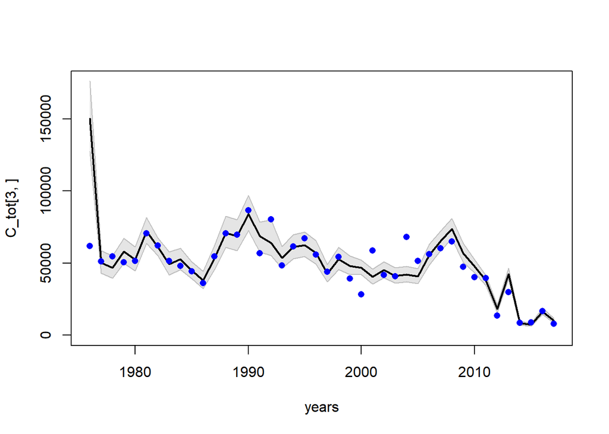

## Age Composition

### George

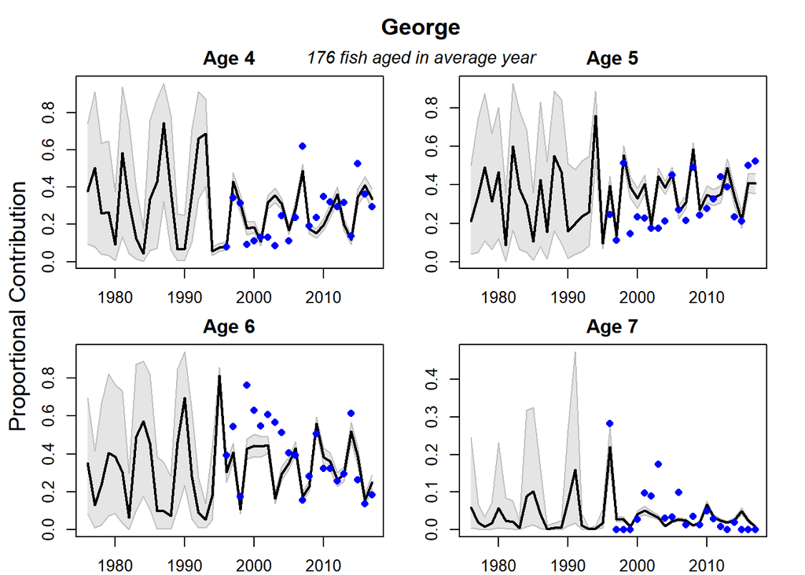

### Kogrukluk

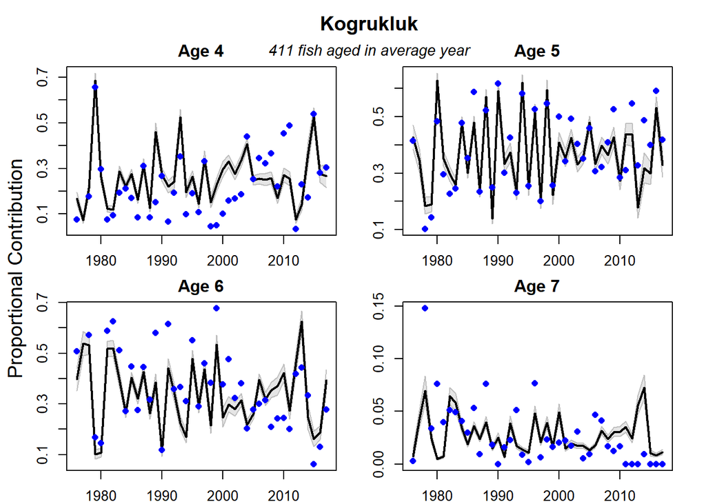

### Kwethluk

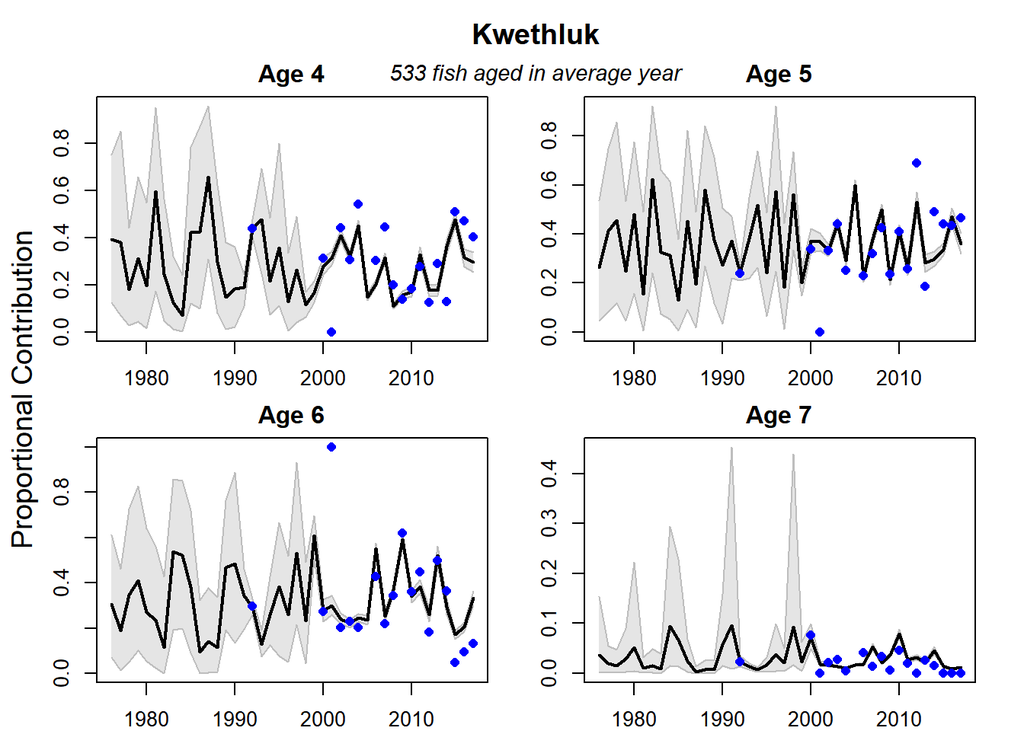

### Takotna

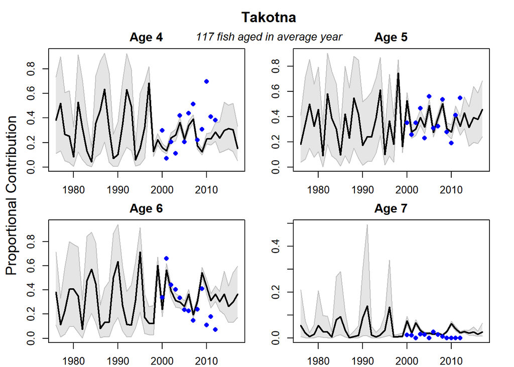

### Tatlawiksuk

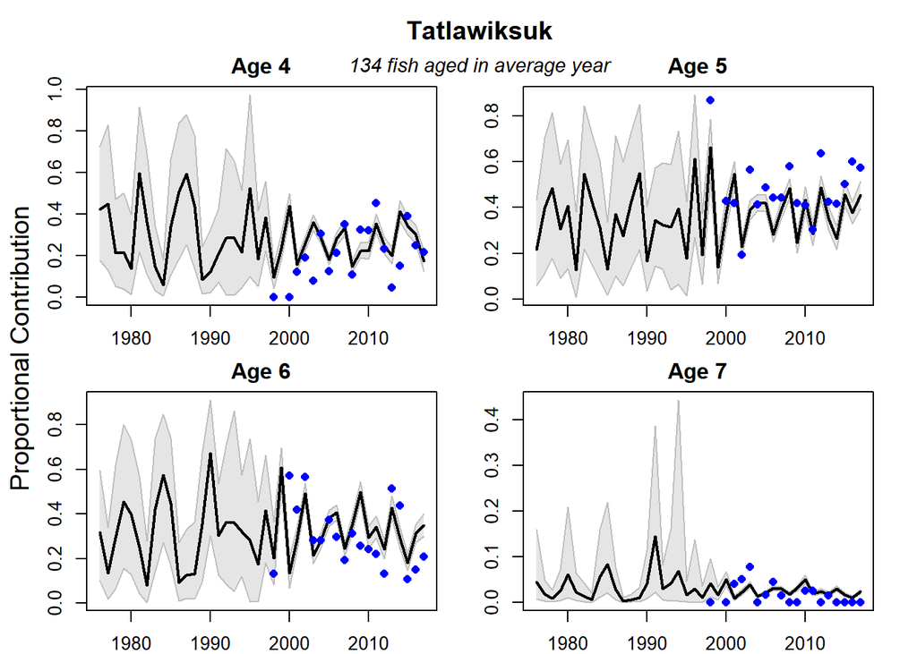

### Tuluksak

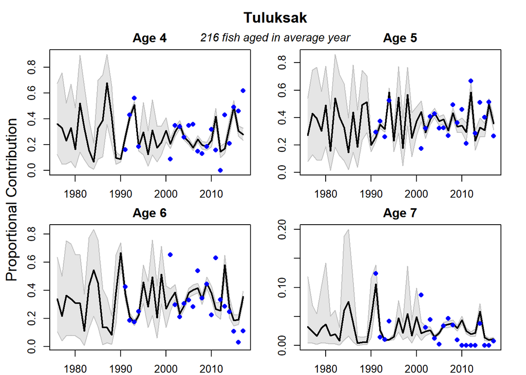

## Recruitment

**NOTE:** The state-space model does not fit to recruitment. It reconstructs recruitment internally by fitting true latent states in the calendar years to observed states of escapement by population, aggregate harvest, and age composition if available. This plot is included only illustrate how well the model’s reconstructions match one rational way of doing it external to the model.

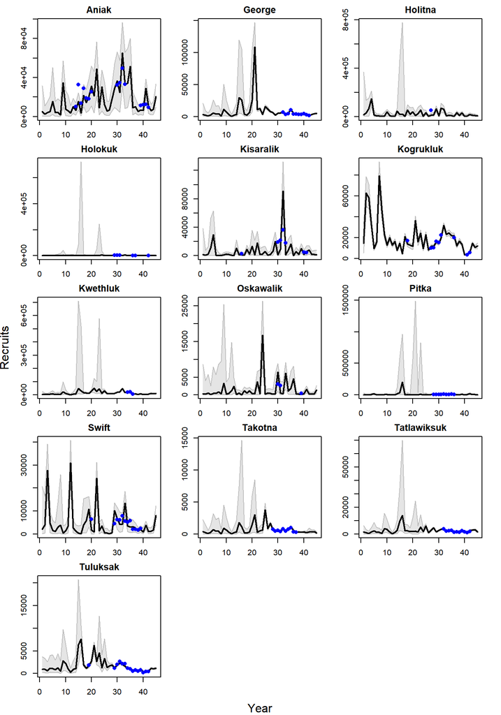

# Recruitment Synchrony

## Recruitment Correlation Estimates

### Scaled Bubbles

Populations are ordered upstream to downstream from top/bottom and left/right. Red circles are negative correlations.

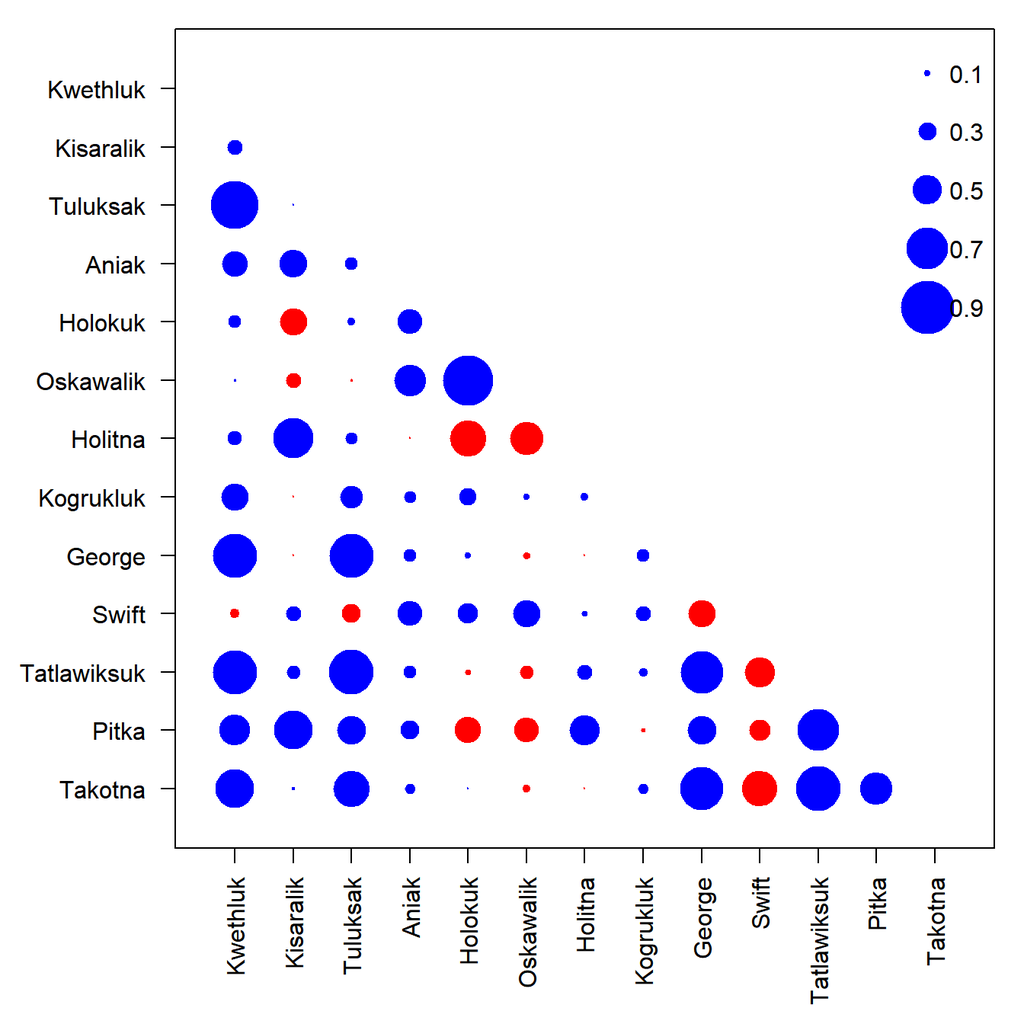

### Numbers

Populations are ordered upstream to downstream from top/bottom and left/right. Black indicates zero was not in the 95% credible interval.

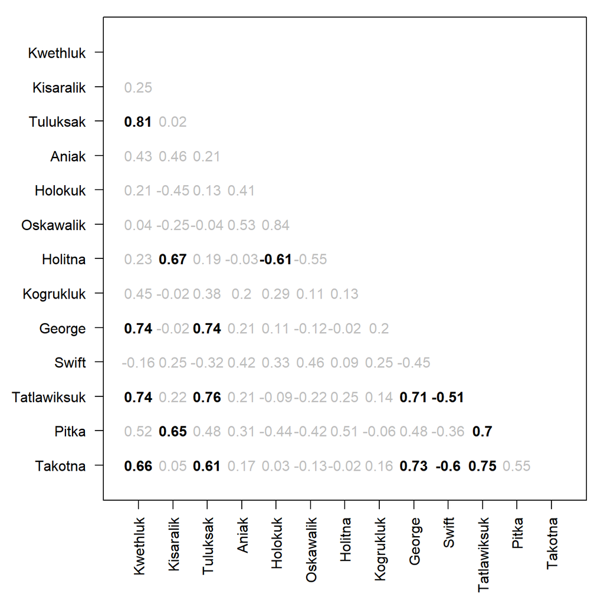

## Recruitment Residuals

### Aggregated

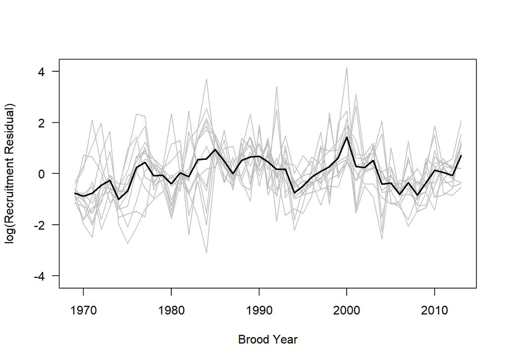

### Separated

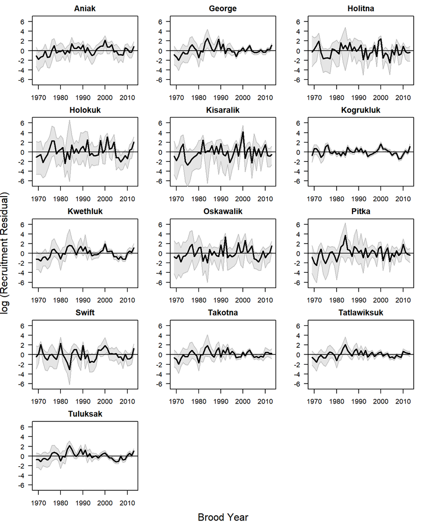

# Trade-offs

## Viz A

Line codes are:

- **Solid**: Escapement
- **Dotted**: Harvest
- **Dashed**: proportion overfished
- **Dotted/Dashed**: proportion extirpated

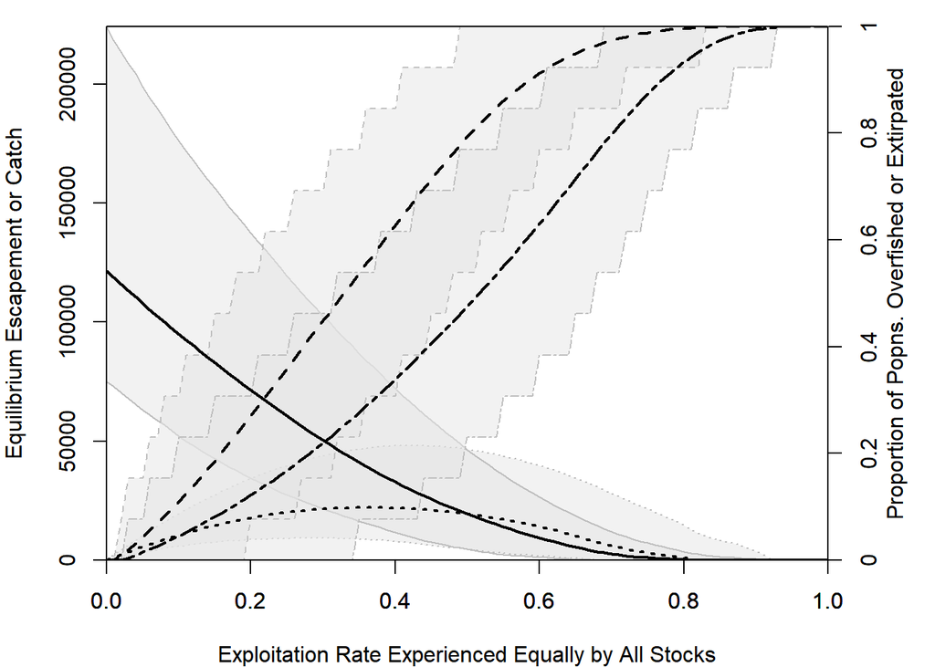

## Viz B

Points represent the mixed-stock exploitation rate. The *x*-axis is the fraction of the mixed-stock MSY attainable, and the *y*-axis is the proportion of populations **not** overfished or **not** trending towards extirpation.

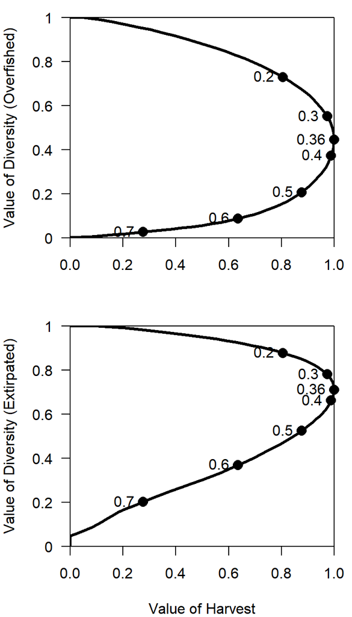

# Mixed-Stock Reference Points

In the table below:

- $S^*_p$ is the minimum escapement of the mixed-stock that is expected to have no more than $p \cdot 100$% of the populations overfished
- $U^*_p$ is the maximum exploitation rate of the mixed-stock that is expected to have no more than $p \cdot 100$% of the populations overfished
- $S_{\text{MSY}}$ and $U_{\text{MSY}}$ are the mixed stock escapement and exploitation rate, respectively, expected to produce maximum sustained yield.

**These reference points are for only the 13 populations included in the analysis, not all populations in the Kuskokwim River.**

| Ref. Point | Median | 2.5% | 97.5% |
| --- | --- | --- | --- |
| $S^*_{0.1}$ | 91,600 | 58,600 | 166,400 |
| $S^*_{0.3}$ | 72,100 | 44,100 | 127,900 |
| $S^*_{0.5}$ | 46,300 | 27,000 | 83,200 |
| $S_{\text{MSY}}$ | 40,400 | 13,500 | 92,400 |
| $U^*_{0.1}$ | 0.11 | 0.02 | 0.26 |
| $U^*_{0.3}$ | 0.2 | 0.07 | 0.35 |
| $U^*_{0.5}$ | 0.32 | 0.17 | 0.47 |
| $U_{\text{MSY}}$ | 0.38 | 0.2 | 0.59 |

# JAGS Model

## Code

```
model
{
    log_resid_0a <- 0
    phi ~ dunif(-0.99, 0.99)
    for (s in 1:ns) {
        U_msy[s] ~ dunif(0.01, 0.99)
        log_S_msy[s] ~ dnorm(0, 0.001)  I(1, 11.5)
        S_msy[s] <- exp(log_S_msy[s])
        alpha[s] <- exp(U_msy[s])/(1 - U_msy[s])
        log_alpha[s] <- log(alpha[s])
        beta[s] <- U_msy[s]/S_msy[s]
        log_resid_0[s] <- log_resid_0a
    }
    Tau_R[1:ns, 1:ns] ~ dwish(R_wish[1:ns, 1:ns], df_wish)
    Sigma_R[1:ns, 1:ns] <- inverse(Tau_R)
    for (s in 1:ns) {
        sigma_R[s] <- sqrt(Sigma_R[s, s])
    }
    for (i in 1:ns) {
        for (j in 1:ns) {
            rho_mat[i, j] <- Sigma_R[i, j]/(sigma_R[i] * sigma_R[j])
        }
    }
    for (s in 1:ns) {
        R_eq[s] <- log_alpha[s]/beta[s]
        R0[s] <- R_eq[s]
        log_R0[s] <- log(R0[s])
        log_R_mean1[1, s] <- log_R0[s]
        R_mean1[1, s] <- R0[s]
        log_R_mean2[1, s] <- log_R_mean1[1, s] + phi * log_resid_0[s]
        for (y in 2:a_max) {
            R_mean1[y, s] <- R0[s]
            log_R_mean1[y, s] <- log_R0[s]
            log_R_mean2[y, s] <- log_R_mean1[y, s] + phi * log_resid[y -
                1, s]
        }
        for (y in (a_max + 1):ny) {
            R_mean1[y, s] <- S[y - a_max, s] * exp(log_alpha[s] -
                beta[s] * S[y - a_max, s])
            log_R_mean1[y, s] <- log(R_mean1[y, s])
```

[output cut: 47 more lines]

```
    for (t in 1:nt) {
        log_C_tot[t] <- log(C_tot[t])
        C_tot_t_obs[t] ~ dlnorm(log_C_tot[t], tau_C_obs[t])
    }
    for (i in 1:S_obs_n) {
        log_S[i] <- log(S[S_obs_t[i], S_obs_s[i]])
        S_obs[i] ~ dlnorm(log_S[i], tau_S_obs[i])
    }
    for (i in 1:n_age_stocks) {
        for (t in 1:nt) {
            x_tas_obs[t, 1:na, i] ~ dmulti(q[t, 1:na, i], ESS_ts[t,
                i])
        }
    }
}
```

## Data List

```
## $ns
## [1] 13
##
## $nt
## [1] 42
##
## $ny
## [1] 45
##
## $na
## [1] 4
##
## $a_max
## [1] 7
##
```

[output cut: 464 more lines]